# Student Performance Dataset

[figure not shown]

# **Proven hypothesis**

## *The academic performance of a student depends not only on their academic capabilities but also their socio-economic status.*

## **Imagine this...**

## *You are a headmaster/headmistress, managing a school of thousands of students. How do you create the ideal environment for students to academically excel in their education?*

[figure not shown]

# **ET VOILA!**

# **The Student Forecaster Model**:

# https://student-forecaster.streamlit.app/

# *Step 1:* Exploratory analysis

- Distribution and spread of the data
- Dropping columns which at first look are not relevant

```python
#First glance dropped columns
d1_dropped
```

|  | Columns grouping of data | Reason |
| --- | --- | --- |
| 0 | home address | not relevant to data |
| 1 | parents jobs | over 50percent of data classified as other |
| 2 | attended nursery | studies show attendance no longer relevant |
| 3 | First and second term grades | Final grade, G3 only important target variable |

# *Step 2:* Creating subgroups of data

- To map out relationships between columns of data

```python
#Subgrouping of data columns
df3
```

|  | original columns | Sub-group |
| --- | --- | --- |
| 0 | age, Dalc,Walc, health | alcohol intake during weekday and weekend |
| 1 | famsize, Pstatus, guardian, famrel | quality of family relationships |
| 2 | studytime,activities, freetime, goout, absence... | time related to studying |
| 3 | schoolsup, famsup, paid,higher,failures | extra educational support |
| 4 | school, age, Medu,reason, traveltime, failures... | Impact of reason to pick school |
| 5 | Medu, Fedu | parents level of education |

# *Step 3:* Analysis within sub-groups

- To decide the dominating variables most explaining the target variable

## **Summary of analytical methods used:**

- Heatmap correlation
- Value counts
- Grouping by bins
- Histograms
- Boxplot

## Correlation Heatmap

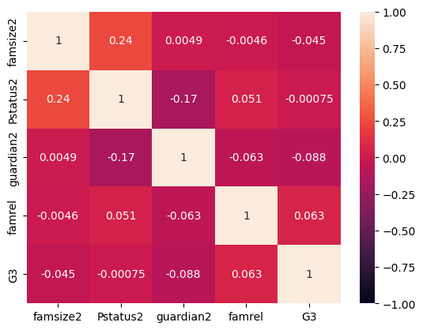

```python
#Heatmap of correlation of the subgroup of family relationships with
#final grade G3
sns.heatmap(df_family2.corr(), vmin=-1, vmax=1, annot=True)
```

## Creating bins and summarising data

```python
# Value counts of grouping of students by age and level of drinking
# during the weekday and weekend
df_alcohol_counted.sort_values(by=['Dalc'])
```

|  | Dalc | Walc | age | count | bins |
| --- | --- | --- | --- | --- | --- |
| 0 | 1 | 1 | 16 | 68 | (14, 17] |
| 8 | 1 | 2 | 15 | 16 | (14, 17] |
| 48 | 1 | 1 | 20 | 2 | (17, 22] |
| 9 | 1 | 3 | 16 | 16 | (14, 17] |
| 7 | 1 | 3 | 17 | 21 | (14, 17] |
| ... | ... | ... | ... | ... | ... |
| 62 | 5 | 1 | 18 | 1 | (17, 22] |
| 61 | 5 | 2 | 21 | 1 | (17, 22] |
| 38 | 5 | 5 | 16 | 3 | (14, 17] |
| 32 | 5 | 5 | 18 | 4 | (17, 22] |
| 81 | 5 | 5 | 22 | 1 | (17, 22] |

82 rows × 5 columns

## Sub-group analysis deduction

```python
# Dataframe of subgroup of data, analytical method used and deductions drawn
df_analysis2
```

[output not shown]

## Conclusion from data

- The biggest impact to G3 is failure
- If a student has failed then they likely have additional support
- Nearly 95% of students want to pursue higher education, so data is heavily skewed
- Over 90% of students do not have paid support but 60% of students have support at home

```python
#Final dataframe of chosen variables for training the model
df_dropped.head()
```

|  | sex | age | Medu | reason | traveltime | studytime | freetime | higher | failures | internet | G3 | G3_binary | G3_binary_label |
| --- | --- | --- | --- | --- | --- | --- | --- | --- | --- | --- | --- | --- | --- |
| 0 | F | 18 | 4 | course | 2 | 2 | 3 | yes | 0 | no | 11 | fail | 0 |
| 1 | F | 17 | 1 | course | 1 | 2 | 3 | yes | 0 | yes | 11 | fail | 0 |
| 2 | F | 15 | 1 | other | 1 | 2 | 3 | yes | 0 | yes | 12 | pass | 1 |
| 3 | F | 15 | 4 | home | 1 | 3 | 2 | yes | 0 | yes | 14 | pass | 1 |
| 4 | F | 16 | 3 | home | 1 | 2 | 3 | yes | 0 | no | 13 | pass | 1 |

# *Machine Learning Part 1:*

## Label encoding the target variable G3

```python
#Label encoding the target variable
df_dropped[['G3_binary',	'G3_binary_label']].head()
```

|  | G3_binary | G3_binary_label |
| --- | --- | --- |
| 0 | fail | 0 |
| 1 | fail | 0 |
| 2 | pass | 1 |
| 3 | pass | 1 |
| 4 | pass | 1 |

# *Machine Learning Part 2:*

## Splitting the train and test data

```python
from sklearn.model_selection import train_test_split

#Split the data into train and test
train_data, test_data = train_test_split(df_dropped, test_size=0.1, random_state=42)

#Ready X and Ys
X_train = train_data[['sex', 'age', 'Medu', 'reason', 'traveltime', 'studytime', 'freetime', 'higher',
       'failures', 'internet']]
y_train = train_data['G3_binary_label']

X_test = test_data[['sex', 'age', 'Medu', 'reason', 'traveltime', 'studytime', 'freetime', 'higher',
       'failures', 'internet']]
y_test = test_data['G3_binary_label']
```

# *Machine Learning Part 3:*

## The pipeline: preprocessing and model

## **Pre-processing pipeline:**

### to *scale the numerical variables* and *One Hot Encode the categorical variables*

```python
# Scale numerical values:
num_transformer = Pipeline([('standard_scaler', StandardScaler())])

# Encode categorical values
cat_transformer = OneHotEncoder()

# Parallelize "num_transformer" and "cat_transfomer"
preprocessor = ColumnTransformer([
    ('num_transformer', num_transformer, ['age','Medu', 'traveltime', 'studytime', 'freetime', 'failures']),
    ('cat_transformer', cat_transformer, ['sex', 'reason', 'higher', 'internet']),
])
```

# The classification model used

```python
model = GradientBoostingClassifier()
```

# *Full pipeline*

```python
pipeline4
```

```
Pipeline(steps=[('preprocessor',
                 ColumnTransformer(transformers=[('num_transformer',
                                                  Pipeline(steps=[('standard_scaler',
                                                                   StandardScaler())]),
                                                  ['age', 'Medu', 'traveltime',
                                                   'studytime', 'freetime',
                                                   'failures']),
                                                 ('cat_transformer',
                                                  OneHotEncoder(),
                                                  ['sex', 'reason', 'higher',
                                                   'internet'])])),
                ('boosting', GradientBoostingClassifier())])
```

# *Machine Learning Part 4:*

## *Training, fitting and comparing scoring metrics across different models*

```python
#Comparisons of different models tried and tested
df_model
```

|  | model used | precision | Test vs Train precision CV | Over/Underfitting |
| --- | --- | --- | --- | --- |
| 0 | Lgistic Regression | 0.75 | 0.72 vs 0.72 | No Overfitting |
| 1 | KNN KNeighborsClassifier | 0.76 | 0.67 vs 0.83 | Overfitting |
| 2 | Random Forest Classifier | 0.81 | 0.70 vs 0.98 | Overfitting |
| 3 | XGB Classifier | 0.82 | 0.68 vs 0.95 | Overfitting |
| 4 | Gradient Boosting Classifier | 0.76 | 0.70 vs 0.78 | Slightly Overfitting |

# **Detail on the classification model chosen:**

## *Gradient Boosting Classifier*

- Good scoring metrics
- Less overfitting on training data

```python
print("Accuracy:",round(accuracy,2))
print("Precision:", round(precision,2))
print("Recall:", round(recall,2))
print("F1 Score:", round(f1,2))
```

```
Accuracy: 0.77
Precision: 0.76
Recall: 0.9
F1 Score: 0.82
```

# *Thank you for your attention*

[figure not shown]